# Predicciones de precio de venta de casas con datos trail y test

#### Ordenar de mayor a menor las correlaciones de SalePrice

- Crear un conjunto de datos ordenado de mayor a menor por el valor de la correlación del precio de ventas con las demás variables
- Determinar head(), las mejores seis correlaciones con el SalePrice

```r
entrenaCol.Correl.Price <- arrange(entrenaCol.Correl.Price, desc(correlacion))
entrenaCol.Correl.Price
```

```
##         variable         correlacion
## 1      SalePrice                   1
## 2    OverallQual   0.790981600583805
## 3      GrLivArea   0.708624477612652
## 4     GarageCars   0.640409197258352
## 5     GarageArea   0.623431438918362
## 6    TotalBsmtSF   0.613580551559196
## 7       1stFlrSF   0.605852184691915
## 8       FullBath   0.560663762748446
## 9   TotRmsAbvGrd   0.533723155582028
## 10     YearBuilt   0.522897332879497
## 11  YearRemodAdd   0.507100967111386
## 12    Fireplaces   0.466928836751528
## 13    BsmtFinSF1   0.386419806242153
## 14    WoodDeckSF    0.32441344456813
```

[output cut: 24 more lines]

```r
head(entrenaCol.Correl.Price)
```

```
##      variable       correlacion
## 1   SalePrice                 1
## 2 OverallQual 0.790981600583805
## 3   GrLivArea 0.708624477612652
## 4  GarageCars 0.640409197258352
## 5  GarageArea 0.623431438918362
## 6 TotalBsmtSF 0.613580551559196
```

- Las columnas mas correlaciones con SalePrice OverallQual, GrLivArea, GarageCars, GarageArea, TotalBsmtSF, 1stFlrSF
- La variable 1stFlrSF comienza con número, para efecto de procesar adecuadamente el modelo se debe renombrar, al igual que otras dos variables más adelante vistas

#### Algunos diagramas de dispersión con e´stas variables en relación a SalePrice

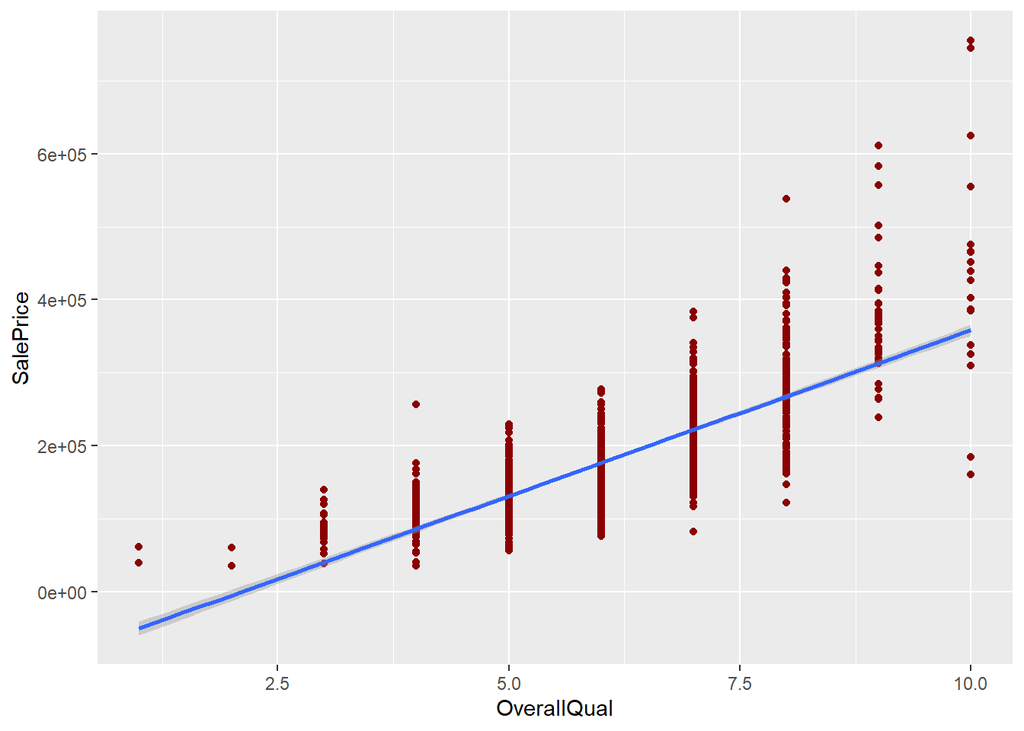

```r
ggplot(entrenaNumericas, aes(x=OverallQual, y=SalePrice)) +
  geom_point(color="darkred") + geom_smooth(method = "lm")
```

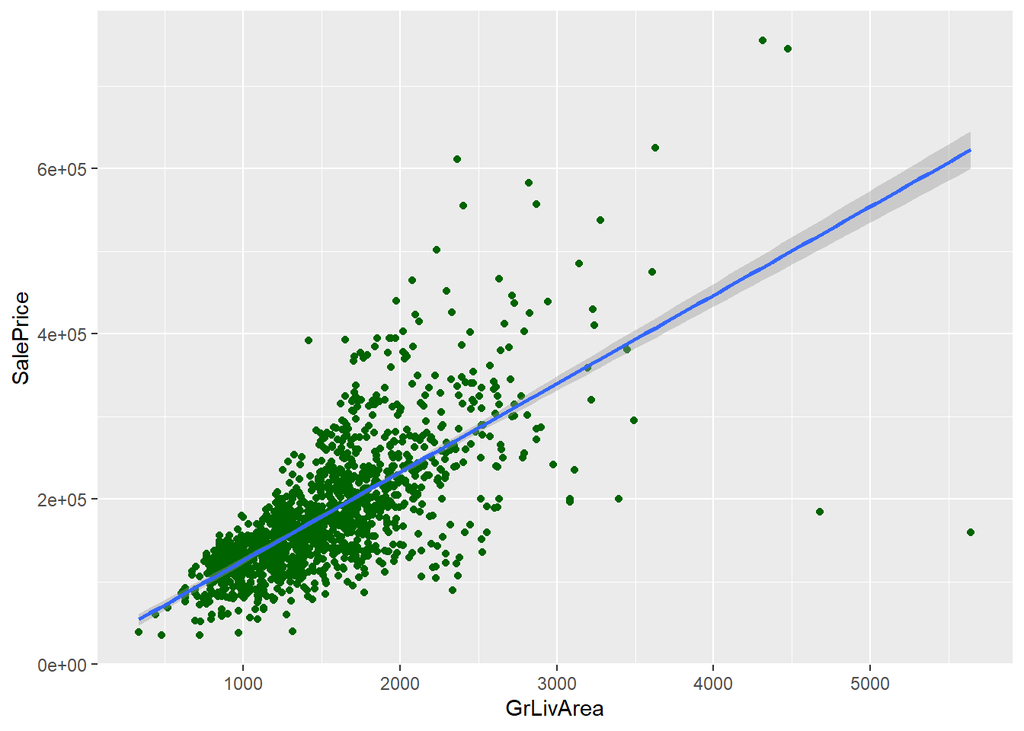

```r
ggplot(entrenaNumericas, aes(x=GrLivArea, y=SalePrice)) +
  geom_point(color="darkgreen") + geom_smooth(method = "lm")
```

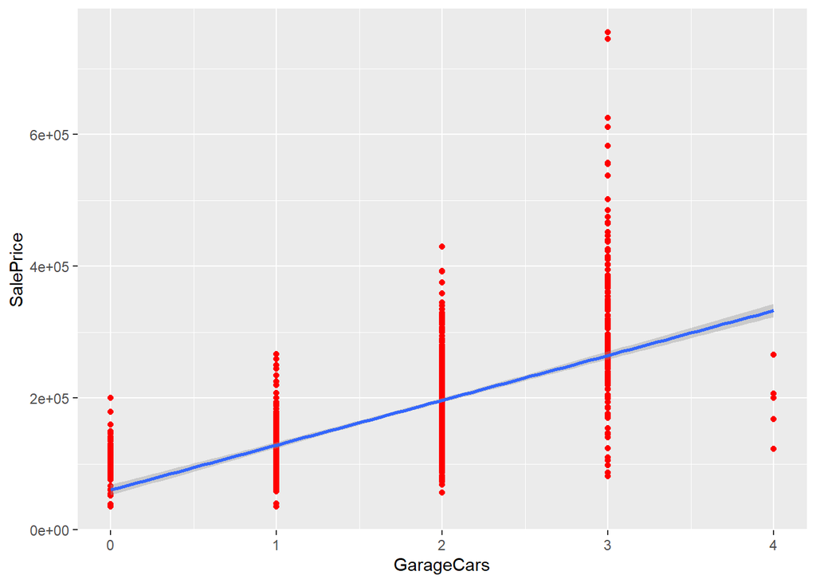

```r
ggplot(entrena, aes(x=GarageCars, y=SalePrice)) +
  geom_point(color="red") + geom_smooth(method = "lm")
```

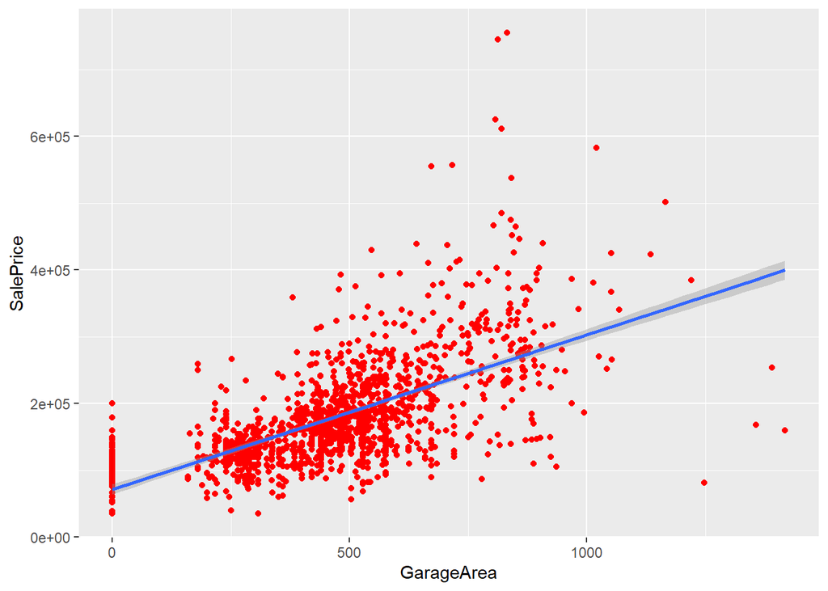

```r
ggplot(entrenaNumericas, aes(x=GarageArea, y=SalePrice)) +
  geom_point(color="red") + geom_smooth(method = "lm")
```

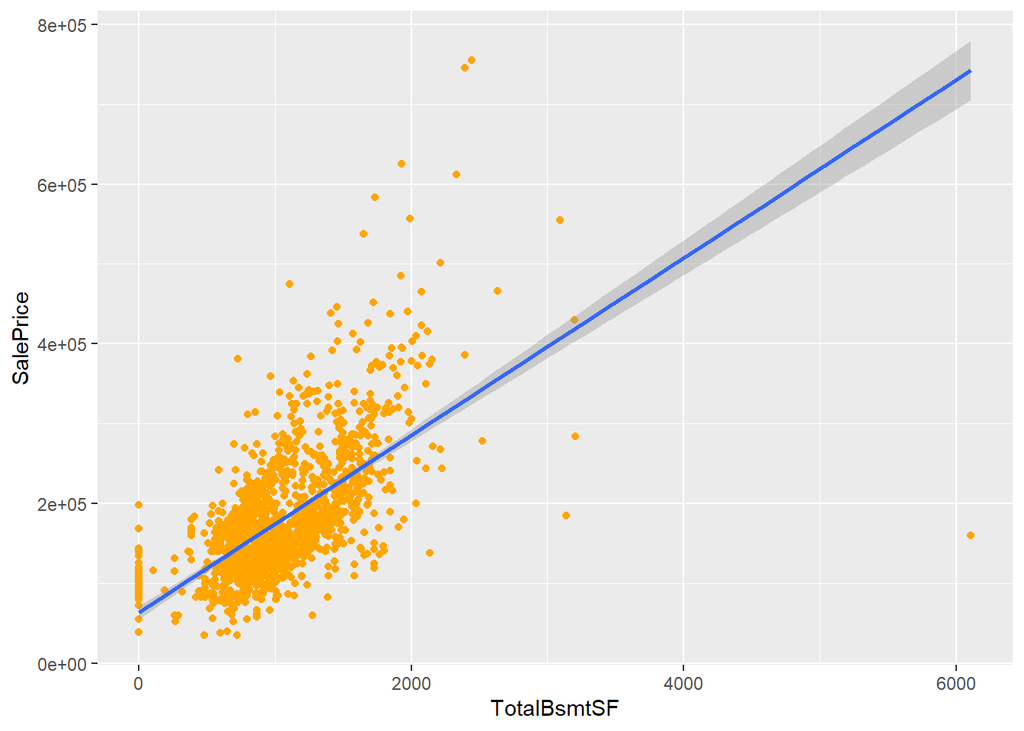

```r
ggplot(entrenaNumericas, aes(x=TotalBsmtSF, y=SalePrice)) +
  geom_point(color="orange") + geom_smooth(method = "lm")
```

[figure not shown]

```r
ggplot(entrenaNumericas, aes(x="1stFlrSF", y=SalePrice)) +
  geom_point(color="purple") + geom_smooth(method = "lm")
```

#### Modelo de regresión lineal mútiple

##### modelo1

```r
entrenaNumericas = rename(entrenaNumericas, c(`1stFlrSF`="lstFlrSF"))  # opcion 2, renombra la variable
```

##### modelo1

```r
modelo1 <- lm(formula = SalePrice ~ OverallQual +
               GrLivArea + GarageCars + GarageArea +
               TotalBsmtSF +  + FullBath + lstFlrSF +
                TotRmsAbvGrd + YearBuilt + YearRemodAdd, entrenaNumericas)
summary(modelo1)
```

```
##
## Call:
## lm(formula = SalePrice ~ OverallQual + GrLivArea + GarageCars +
##     GarageArea + TotalBsmtSF + +FullBath + lstFlrSF + TotRmsAbvGrd +
##     YearBuilt + YearRemodAdd, data = entrenaNumericas)
##
## Residuals:
##     Min      1Q  Median      3Q     Max
## -489958  -19316   -1948   16020  290558
##
## Coefficients:
##                Estimate Std. Error t value Pr(>|t|)
## (Intercept)  -1.186e+06  1.291e+05  -9.187  < 2e-16 ***
## OverallQual   1.960e+04  1.190e+03  16.472  < 2e-16 ***
## GrLivArea     5.130e+01  4.233e+00  12.119  < 2e-16 ***
## GarageCars    1.042e+04  3.044e+03   3.422 0.000639 ***
## GarageArea    1.495e+01  1.031e+01   1.450 0.147384
## TotalBsmtSF   1.986e+01  4.295e+00   4.625 4.09e-06 ***
## FullBath     -6.791e+03  2.682e+03  -2.532 0.011457 *
## lstFlrSF      1.417e+01  4.930e+00   2.875 0.004097 **
## TotRmsAbvGrd  3.310e+01  1.119e+03   0.030 0.976404
## YearBuilt     2.682e+02  5.035e+01   5.328 1.15e-07 ***
## YearRemodAdd  2.965e+02  6.363e+01   4.659 3.47e-06 ***
## ---
## Signif. codes:  0 '***' 0.001 '**' 0.01 '*' 0.05 '.' 0.1 ' ' 1
##
## Residual standard error: 37920 on 1449 degrees of freedom
## Multiple R-squared:  0.7737, Adjusted R-squared:  0.7721
## F-statistic: 495.4 on 10 and 1449 DF,  p-value: < 2.2e-16
```

#### Interpretación del modelo1

- En los modelos lineales múltiples, cuantos más predictores se incluyan en el modelo mayor es el valor de R2, ya que, por poco que sea, cada predictor va a explicar una parte de la variabilidad observada en Y.
- Es por esto que R2 no puede utilizarse para comparar modelos con distinto número de predictores
- R2ajustado introduce una penalización al valor de R2 por cada predictor que se introduce en el modelo.
- El valor de la penalización depende del número de predictores utilizados y del tamaño de la muestra, es decir, del número de grados de libertad.
- Cuanto mayor es el tamaño de la muestra, más predictores se pueden incorporar en el modelo.
- R2ajustado permite encontrar el mejor modelo, aquel que consigue explicar mejor la variabilidad de Y con el menor número de predictores

##### modelo2

- Crear un modelo con todas las variables numéricas en el conjnto de datos de entrenamiento
- Antes se debe cambiar nombres a ciertas variables que empiezan con caracter 2 y 3 respectivamente
- entrenaNumericas$tndFlrSF <- entrena$`2ndFlrSF`
- entrenaNumericas$tSsnPorch <- entrena$`3SsnPorch`

```r
entrenaNumericas = rename(entrenaNumericas, c(`2ndFlrSF`="tndFlrSF"))  # renombra la variable
entrenaNumericas = rename(entrenaNumericas, c(`3SsnPorch`="tSsnPorch"))  # renombra la variable

modelo2 <- lm(formula = SalePrice ~ ., data = entrenaNumericas)
modelo2
```

```
##
## Call:
## lm(formula = SalePrice ~ ., data = entrenaNumericas)
##
## Coefficients:
##   (Intercept)             Id     MSSubClass    LotFrontage        LotArea
##    -3.351e+05     -1.205e+00     -2.001e+02     -1.160e+02      5.422e-01
##   OverallQual    OverallCond      YearBuilt   YearRemodAdd     MasVnrArea
##     1.866e+04      5.239e+03      3.164e+02      1.194e+02      3.141e+01
##    BsmtFinSF1     BsmtFinSF2      BsmtUnfSF    TotalBsmtSF       lstFlrSF
##     1.736e+01      8.342e+00      5.005e+00             NA      4.597e+01
##      tndFlrSF   LowQualFinSF      GrLivArea   BsmtFullBath   BsmtHalfBath
##     4.663e+01      3.341e+01             NA      9.043e+03      2.465e+03
##      FullBath       HalfBath   BedroomAbvGr   KitchenAbvGr   TotRmsAbvGrd
##     5.433e+03     -1.098e+03     -1.022e+04     -2.202e+04      5.464e+03
##    Fireplaces    GarageYrBlt     GarageCars     GarageArea     WoodDeckSF
##     4.372e+03     -4.728e+01      1.685e+04      6.274e+00      2.144e+01
##   OpenPorchSF  EnclosedPorch      tSsnPorch    ScreenPorch       PoolArea
##    -2.252e+00      7.295e+00      3.349e+01      5.805e+01     -6.052e+01
##       MiscVal         MoSold         YrSold
##    -3.761e+00     -2.217e+02     -2.474e+02
```

```r
summary(modelo2)
```

```
##
## Call:
## lm(formula = SalePrice ~ ., data = entrenaNumericas)
##
## Residuals:
##     Min      1Q  Median      3Q     Max
## -442182  -16955   -2824   15125  318183
##
## Coefficients: (2 not defined because of singularities)
##                 Estimate Std. Error t value Pr(>|t|)
## (Intercept)   -3.351e+05  1.701e+06  -0.197 0.843909
## Id            -1.205e+00  2.658e+00  -0.453 0.650332
## MSSubClass    -2.001e+02  3.451e+01  -5.797 8.84e-09 ***
## LotFrontage   -1.160e+02  6.126e+01  -1.894 0.058503 .
## LotArea        5.422e-01  1.575e-01   3.442 0.000599 ***
## OverallQual    1.866e+04  1.482e+03  12.592  < 2e-16 ***
## OverallCond    5.239e+03  1.368e+03   3.830 0.000135 ***
## YearBuilt      3.164e+02  8.766e+01   3.610 0.000321 ***
## YearRemodAdd   1.194e+02  8.668e+01   1.378 0.168607
## MasVnrArea     3.141e+01  7.022e+00   4.473 8.54e-06 ***
## BsmtFinSF1     1.736e+01  5.838e+00   2.973 0.003014 **
## BsmtFinSF2     8.342e+00  8.766e+00   0.952 0.341532
## BsmtUnfSF      5.005e+00  5.277e+00   0.948 0.343173
## TotalBsmtSF           NA         NA      NA       NA
## lstFlrSF       4.597e+01  7.360e+00   6.246 6.02e-10 ***
## tndFlrSF       4.663e+01  6.102e+00   7.641 4.72e-14 ***
## LowQualFinSF   3.341e+01  2.794e+01   1.196 0.232009
## GrLivArea             NA         NA      NA       NA
## BsmtFullBath   9.043e+03  3.198e+03   2.828 0.004776 **
## BsmtHalfBath   2.465e+03  5.073e+03   0.486 0.627135
## FullBath       5.433e+03  3.531e+03   1.539 0.124182
## HalfBath      -1.098e+03  3.321e+03  -0.331 0.740945
## BedroomAbvGr  -1.022e+04  2.155e+03  -4.742 2.40e-06 ***
## KitchenAbvGr  -2.202e+04  6.710e+03  -3.282 0.001063 **
## TotRmsAbvGrd   5.464e+03  1.487e+03   3.674 0.000251 ***
## Fireplaces     4.372e+03  2.189e+03   1.998 0.046020 *
## GarageYrBlt   -4.728e+01  9.106e+01  -0.519 0.603742
## GarageCars     1.685e+04  3.491e+03   4.827 1.58e-06 ***
## GarageArea     6.274e+00  1.213e+01   0.517 0.605002
## WoodDeckSF     2.144e+01  1.002e+01   2.139 0.032662 *
## OpenPorchSF   -2.252e+00  1.949e+01  -0.116 0.907998
## EnclosedPorch  7.295e+00  2.062e+01   0.354 0.723590
## tSsnPorch      3.349e+01  3.758e+01   0.891 0.373163
## ScreenPorch    5.805e+01  2.041e+01   2.844 0.004532 **
## PoolArea      -6.052e+01  2.990e+01  -2.024 0.043204 *
## MiscVal       -3.761e+00  6.960e+00  -0.540 0.589016
## MoSold        -2.217e+02  4.229e+02  -0.524 0.600188
## YrSold        -2.474e+02  8.458e+02  -0.293 0.769917
## ---
## Signif. codes:  0 '***' 0.001 '**' 0.01 '*' 0.05 '.' 0.1 ' ' 1
##
## Residual standard error: 36800 on 1085 degrees of freedom
##   (339 observations deleted due to missingness)
## Multiple R-squared:  0.8096, Adjusted R-squared:  0.8034
## F-statistic: 131.8 on 35 and 1085 DF,  p-value: < 2.2e-16
```

##### modelo3

- Se crea un modelo de regresión mútiple con algunas variables elegidas aleatoriamente por el analista

```r
modelo3 <- lm(formula = SalePrice ~ LotArea +
                OverallQual + OverallCond + YearBuilt +
                BsmtFinSF1 + lstFlrSF + tndFlrSF +
                BedroomAbvGr + TotRmsAbvGrd + GarageCars +ScreenPorch, entrenaNumericas )
modelo3
```

```
##
## Call:
## lm(formula = SalePrice ~ LotArea + OverallQual + OverallCond +
##     YearBuilt + BsmtFinSF1 + lstFlrSF + tndFlrSF + BedroomAbvGr +
##     TotRmsAbvGrd + GarageCars + ScreenPorch, data = entrenaNumericas)
##
## Coefficients:
##  (Intercept)       LotArea   OverallQual   OverallCond     YearBuilt
##   -9.425e+05     5.682e-01     2.011e+04     5.951e+03     4.252e+02
##   BsmtFinSF1      lstFlrSF      tndFlrSF  BedroomAbvGr  TotRmsAbvGrd
##    1.837e+01     6.334e+01     4.595e+01    -9.360e+03     4.630e+03
##   GarageCars   ScreenPorch
##    1.213e+04     5.405e+01
```

```r
summary(modelo3)
```

```
##
## Call:
## lm(formula = SalePrice ~ LotArea + OverallQual + OverallCond +
##     YearBuilt + BsmtFinSF1 + lstFlrSF + tndFlrSF + BedroomAbvGr +
##     TotRmsAbvGrd + GarageCars + ScreenPorch, data = entrenaNumericas)
##
## Residuals:
##     Min      1Q  Median      3Q     Max
## -514848  -17297   -1087   14557  287694
##
## Coefficients:
##                Estimate Std. Error t value Pr(>|t|)
## (Intercept)  -9.425e+05  8.999e+04 -10.474  < 2e-16 ***
## LotArea       5.682e-01  1.019e-01   5.577 2.92e-08 ***
## OverallQual   2.011e+04  1.123e+03  17.916  < 2e-16 ***
## OverallCond   5.951e+03  9.467e+02   6.286 4.31e-10 ***
## YearBuilt     4.252e+02  4.595e+01   9.255  < 2e-16 ***
## BsmtFinSF1    1.837e+01  2.432e+00   7.554 7.43e-14 ***
## lstFlrSF      6.334e+01  4.569e+00  13.864  < 2e-16 ***
## tndFlrSF      4.595e+01  3.977e+00  11.555  < 2e-16 ***
## BedroomAbvGr -9.360e+03  1.686e+03  -5.552 3.36e-08 ***
## TotRmsAbvGrd  4.630e+03  1.210e+03   3.826 0.000136 ***
## GarageCars    1.213e+04  1.749e+03   6.937 6.03e-12 ***
## ScreenPorch   5.405e+01  1.724e+01   3.136 0.001748 **
## ---
## Signif. codes:  0 '***' 0.001 '**' 0.01 '*' 0.05 '.' 0.1 ' ' 1
##
## Residual standard error: 36220 on 1448 degrees of freedom
## Multiple R-squared:  0.7937, Adjusted R-squared:  0.7921
## F-statistic: 506.4 on 11 and 1448 DF,  p-value: < 2.2e-16
```

- Este último modeolo representa los siguietne svalores Multiple R-squared: 0.7937, Adjusted R-squared: 0.7921
- Significan que represenan el 79% de la variabilidad del precio de venta

#### Preguntas para el análisis

- ¿Cual modelo de regresión lineal múltiple tomar y porqué?
- ¿Cuáles variables son las que más representan variabilidad al precio de venta de las casas?
- Utilizar el paquete MASS para eliminar variables automáticamente en el modelo
- Se intenta eliminar variables a partir del modelo2 que contiene todas las variables

#### La librería previamente instalada

```r
library(MASS)
```

- se hace una selección de las variables para dentifiar cuales son importantes y cuáles no
- Cuando se dispone de muchas variables explicativas potenciales, las estrategias de regresión anteriores definen normalmente un subconjunto posible de modelos y el problema radica en seleccionar el mejor entre ellos
- Se puede utilizar distintos estadísticos, como }
- el criterio de información de Akaike AIC,
- el criterio de información Bayesiana BIC,
- el coeficiente de determinación R2,
- el coeficiente de determinación corregido R2aj,
- la varianza residual o el estadístico Cp de Mallows
- Para este ejemplo se tom AIC
- La función step() del paquete base stats y stepAIC del paquete MASS, permite seleccionar el método mediante el argumento direction = c(«both», «backward», «forward»).
- Utilizan el AIC como criterio de selección de variables.")

```r
step.modelo2 <- stepAIC(modelo2, direction = "forward")
```

```
## Start:  AIC=23606.14
## SalePrice ~ Id + MSSubClass + LotFrontage + LotArea + OverallQual +
##     OverallCond + YearBuilt + YearRemodAdd + MasVnrArea + BsmtFinSF1 +
##     BsmtFinSF2 + BsmtUnfSF + TotalBsmtSF + lstFlrSF + tndFlrSF +
##     LowQualFinSF + GrLivArea + BsmtFullBath + BsmtHalfBath +
##     FullBath + HalfBath + BedroomAbvGr + KitchenAbvGr + TotRmsAbvGrd +
##     Fireplaces + GarageYrBlt + GarageCars + GarageArea + WoodDeckSF +
##     OpenPorchSF + EnclosedPorch + tSsnPorch + ScreenPorch + PoolArea +
##     MiscVal + MoSold + YrSold
```

```r
summary(step.modelo2)
```

```
##
## Call:
## lm(formula = SalePrice ~ Id + MSSubClass + LotFrontage + LotArea +
##     OverallQual + OverallCond + YearBuilt + YearRemodAdd + MasVnrArea +
##     BsmtFinSF1 + BsmtFinSF2 + BsmtUnfSF + TotalBsmtSF + lstFlrSF +
##     tndFlrSF + LowQualFinSF + GrLivArea + BsmtFullBath + BsmtHalfBath +
##     FullBath + HalfBath + BedroomAbvGr + KitchenAbvGr + TotRmsAbvGrd +
##     Fireplaces + GarageYrBlt + GarageCars + GarageArea + WoodDeckSF +
##     OpenPorchSF + EnclosedPorch + tSsnPorch + ScreenPorch + PoolArea +
##     MiscVal + MoSold + YrSold, data = entrenaNumericas)
##
## Residuals:
##     Min      1Q  Median      3Q     Max
## -442182  -16955   -2824   15125  318183
##
## Coefficients: (2 not defined because of singularities)
##                 Estimate Std. Error t value Pr(>|t|)
## (Intercept)   -3.351e+05  1.701e+06  -0.197 0.843909
## Id            -1.205e+00  2.658e+00  -0.453 0.650332
## MSSubClass    -2.001e+02  3.451e+01  -5.797 8.84e-09 ***
## LotFrontage   -1.160e+02  6.126e+01  -1.894 0.058503 .
## LotArea        5.422e-01  1.575e-01   3.442 0.000599 ***
## OverallQual    1.866e+04  1.482e+03  12.592  < 2e-16 ***
## OverallCond    5.239e+03  1.368e+03   3.830 0.000135 ***
## YearBuilt      3.164e+02  8.766e+01   3.610 0.000321 ***
## YearRemodAdd   1.194e+02  8.668e+01   1.378 0.168607
## MasVnrArea     3.141e+01  7.022e+00   4.473 8.54e-06 ***
## BsmtFinSF1     1.736e+01  5.838e+00   2.973 0.003014 **
## BsmtFinSF2     8.342e+00  8.766e+00   0.952 0.341532
## BsmtUnfSF      5.005e+00  5.277e+00   0.948 0.343173
## TotalBsmtSF           NA         NA      NA       NA
## lstFlrSF       4.597e+01  7.360e+00   6.246 6.02e-10 ***
## tndFlrSF       4.663e+01  6.102e+00   7.641 4.72e-14 ***
## LowQualFinSF   3.341e+01  2.794e+01   1.196 0.232009
## GrLivArea             NA         NA      NA       NA
## BsmtFullBath   9.043e+03  3.198e+03   2.828 0.004776 **
## BsmtHalfBath   2.465e+03  5.073e+03   0.486 0.627135
## FullBath       5.433e+03  3.531e+03   1.539 0.124182
## HalfBath      -1.098e+03  3.321e+03  -0.331 0.740945
## BedroomAbvGr  -1.022e+04  2.155e+03  -4.742 2.40e-06 ***
## KitchenAbvGr  -2.202e+04  6.710e+03  -3.282 0.001063 **
## TotRmsAbvGrd   5.464e+03  1.487e+03   3.674 0.000251 ***
## Fireplaces     4.372e+03  2.189e+03   1.998 0.046020 *
## GarageYrBlt   -4.728e+01  9.106e+01  -0.519 0.603742
## GarageCars     1.685e+04  3.491e+03   4.827 1.58e-06 ***
## GarageArea     6.274e+00  1.213e+01   0.517 0.605002
## WoodDeckSF     2.144e+01  1.002e+01   2.139 0.032662 *
## OpenPorchSF   -2.252e+00  1.949e+01  -0.116 0.907998
## EnclosedPorch  7.295e+00  2.062e+01   0.354 0.723590
## tSsnPorch      3.349e+01  3.758e+01   0.891 0.373163
## ScreenPorch    5.805e+01  2.041e+01   2.844 0.004532 **
## PoolArea      -6.052e+01  2.990e+01  -2.024 0.043204 *
## MiscVal       -3.761e+00  6.960e+00  -0.540 0.589016
## MoSold        -2.217e+02  4.229e+02  -0.524 0.600188
## YrSold        -2.474e+02  8.458e+02  -0.293 0.769917
## ---
## Signif. codes:  0 '***' 0.001 '**' 0.01 '*' 0.05 '.' 0.1 ' ' 1
##
## Residual standard error: 36800 on 1085 degrees of freedom
##   (339 observations deleted due to missingness)
## Multiple R-squared:  0.8096, Adjusted R-squared:  0.8034
## F-statistic: 131.8 on 35 and 1085 DF,  p-value: < 2.2e-16
```